# Task 5

```r
# load in the required packages
library(tidyverse)
library(here)
library(ggplot2)

# read in the clean data
rw_data <- read_csv(here("data/clean_data/clean_rwa.csv"))
```

# Right-Wing Authoritarianism Survey Response Analysis

## Data Cleaning Process

The initial dirty data has been passed through a cleaning script which has:

- added a unique ID no for each participant
- lengthened the data - initially each question number had it’s own column. This was changed to long form for wrangling. Each question for each participant had one row. Multiple rows are now attributed to each participant.
- taken a subset of the columns of the dirty data - only the survey responses relating to RWA index were desired for analysis.
- converted reverse scoring questions to the correct score:

```r
    mutate(response = case_when(
      survey_question == 4|6|8|9|11|13|15|18|20|21 ~ 10 - response,
      TRUE ~ response
    ))
```

- converted 0 responses to NA so they can be excluded (the survey responses should only be between 1 and 10 (inclusive)).
- calculated an average RWA index for each participant and added this to a new column. NA values have been included so if a participant failed to respond to a question their average RWAI will be NA. This is to keep the average calculation consistent for all participants:

```r
    group_by(participant_no) %>%
    filter(survey_question > 2) %>%
    mutate(avg_rwa = mean(response, na.rm = FALSE))
```

- recoded several columns so that they include more information. e.g.

```r
marital_statuses <- c("never married",
                        "currently married",
                        "previously married")

married = case_when(
      married == 1 ~ marital_statuses[1],
      married == 2 ~ marital_statuses[2],
      married == 3 ~ marital_statuses[3]
    )
```

- renamed columns to more appropriate names and so they are in accordance with syle guide
- filtered non-sensical data: e.g. family size > 13, or age < 0 where false data has clearly been entered. Only where the data is clearly false, has it been removed.
- asserted the data is in clean form
- written the now-clean data to a new CSV, ready for analysis

### Average RWA score per gender

Gender is one of the collected variables, so they can be grouped together based on their response and then the average for each gender can be calculated

```r
rw_data %>%
  group_by(gender) %>%
  summarise(average_rwai_per_gender = mean(avg_rwa, na.rm = TRUE),
            .groups = 'drop_last')
```

| gender | average_rwai_per_gender |
| --- | --- |
| female | 4.866255 |
| male | 4.894754 |
| other | 4.941146 |
| NA | 4.792105 |

### Average RWAI for left handed vs. right handed people

Whether a participant was right, left, or both handed was recorded. Participants can be grouped by their “handedness” and then the average average RWA can be calculated for each handed group.

```r
rw_data %>%
  group_by(handedness) %>%
  summarise(average_rwai_per_hand_group = mean(avg_rwa, na.rm = TRUE),
            .groups = 'drop_last') %>%
  drop_na()
```

| handedness | average_rwai_per_hand_group |
| --- | --- |
| both | 4.815136 |
| left | 4.868673 |
| right | 4.890330 |

### Average RWAI per size of family.

I don’t know exactly what this question is asking for. I took it to mean: what is the average RW score per family size, since literaly translated the question doesn’t make sense - i.e. the average family size for each type of childhood will be the same as the family size, no?

```r
rw_data %>%
  group_by(family_size) %>%
  summarise(average_rwai_per_family_size = mean(avg_rwa, na.rm = TRUE),
            .groups = 'drop_last')
```

| family_size | average_rwai_per_family_size |
| --- | --- |
| 1 | 4.883886 |
| 2 | 4.867887 |
| 3 | 4.888903 |
| 4 | 4.922375 |
| 5 | 4.939925 |
| 6 | 4.897697 |
| 7 | 4.963580 |
| 8 | 5.134314 |
| 9 | 4.915517 |
| 10 | 4.960000 |

[output cut: 3 more lines]

### Average test time per education level

Does a persons level of education have an impact on how long it took them to complete the test?

Education is a measured variable in the data, so it can be easily grouped by and then the average test time for each can be calculated. Here the median average was preferred over the mean average. This is because a tiny minority of the participants took an enormous time to complete the test (maybe they left it and came back to it).

```r
rw_data %>%
  group_by(education_level) %>%
  summarise(avg_time = median(test_elapse_t, na.rm = TRUE),
            .groups = 'drop_last')
```

| education_level | avg_time |
| --- | --- |
| graduate degree | 215.0 |
| high school | 231.0 |
| less than high school | 234.0 |
| university degree | 225.0 |
| NA | 234.5 |

```r
rw_data %>%
  group_by(education_level) %>%
  summarise(median(survey_elapse_t, na.rm = TRUE), .groups = 'drop_last')
```

| education_level | median(survey_elapse_t, na.rm = TRUE) |
| --- | --- |
| graduate degree | 168 |
| high school | 156 |
| less than high school | 147 |
| university degree | 163 |
| NA | 148 |

```r
avg_time_per_ed_level_tibble <- rw_data %>%
  group_by(education_level) %>%
  summarise(avg_test_time = median(test_elapse_t, na.rm = TRUE),
            .groups = 'drop_last') %>%
  drop_na()
```

### Plot results

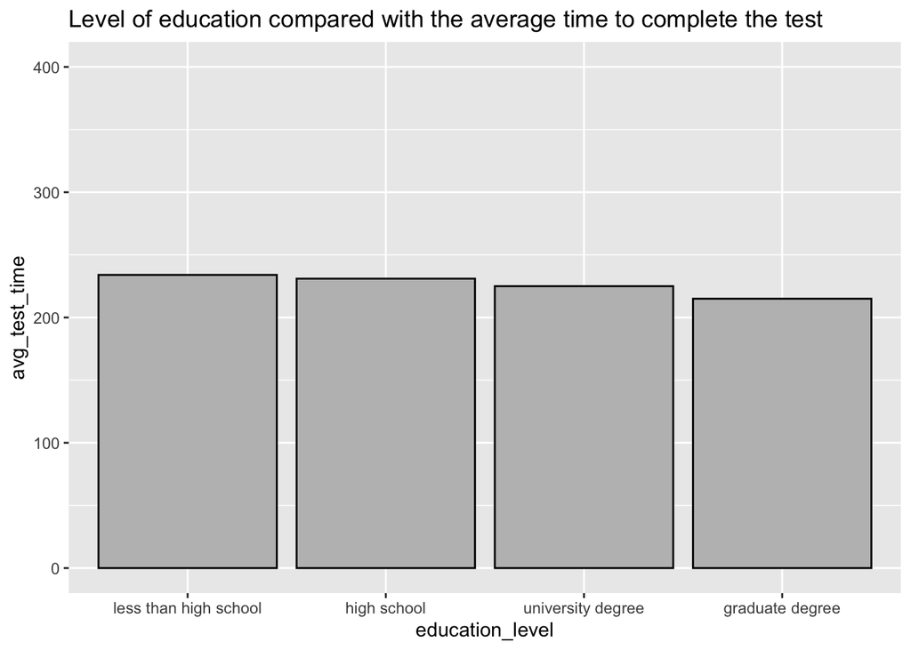

### Average RWAI per age group

What’s the average RWA score for people in different age bands?

This can be answered first by splitting people into the desired age-bands:

- under 18s,
- 18-25 yr olds,
- 26-40 yr olds,
- 41-60 yr olds
- 61+

and then by grouping based on which age band participants fall in and calculating the average for that age band.

```r
avg_per_age_band <- rw_data %>%
  mutate(age_band = case_when(
    age < 18 ~ "under 18",
    age < 26 ~ "18-25",
    age < 41 ~ "26-40",
    age < 61 ~ "41-60",
    age >= 61 ~ "61+"
  )) %>%
  select(participant_no, age_band, avg_rwa) %>%
  group_by(age_band) %>%
  summarise(avg_rwa_for_age_band = mean(avg_rwa, na.rm = TRUE),
            .groups = 'drop_last') %>%
  drop_na()
```

The average right wing authoritarian index score can be plotted for each age band. Again the score relates to a scale of 1-10, with 1 being not RWA and 10 being RWA.

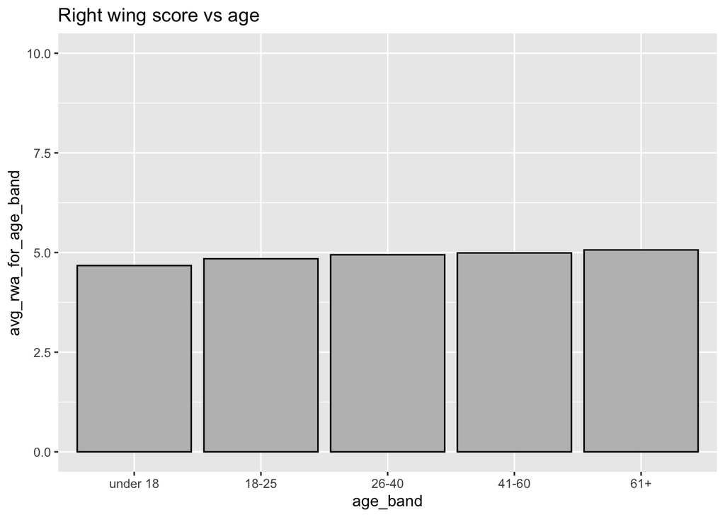

```r
avg_rwa_per_country <- rw_data %>%
  group_by(country_ip) %>%
  summarise(average_rwa = mean(avg_rwa, na.rm = TRUE),
            .groups = 'drop_last') %>%
  drop_na()
```

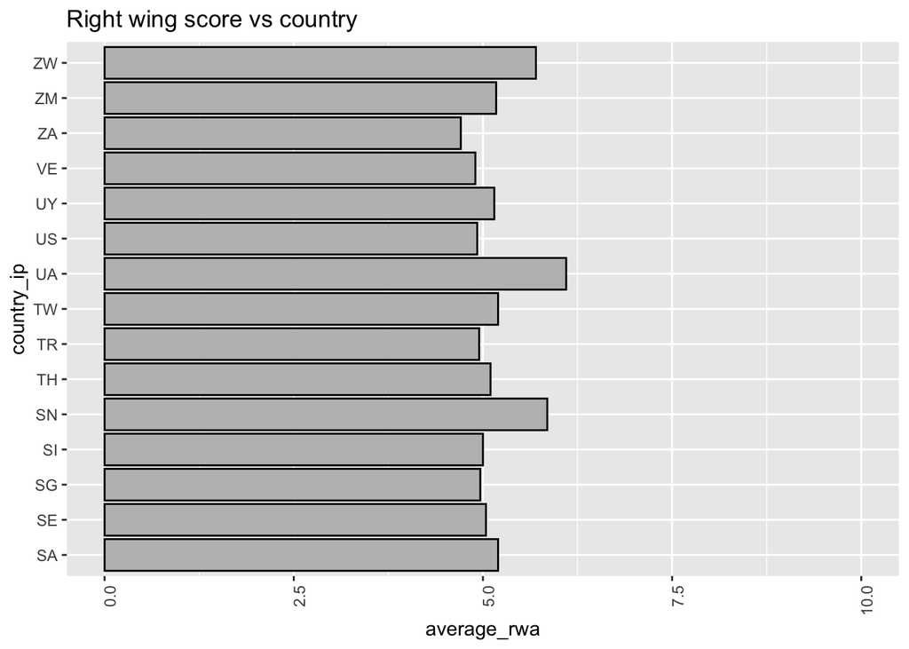

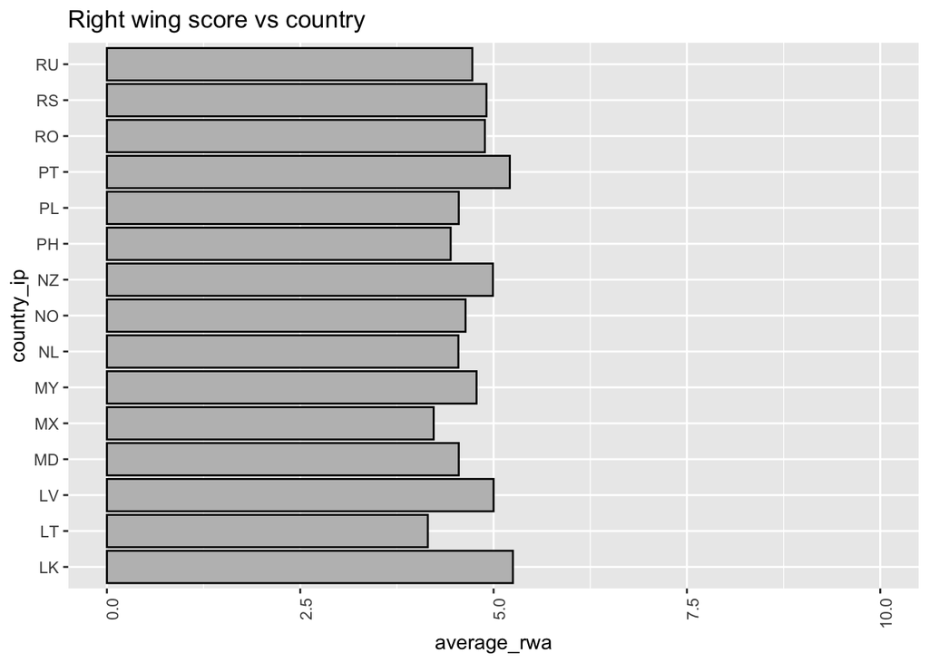

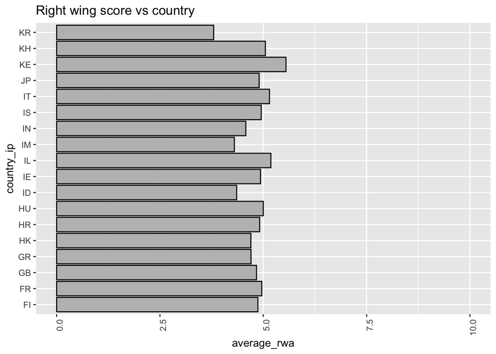

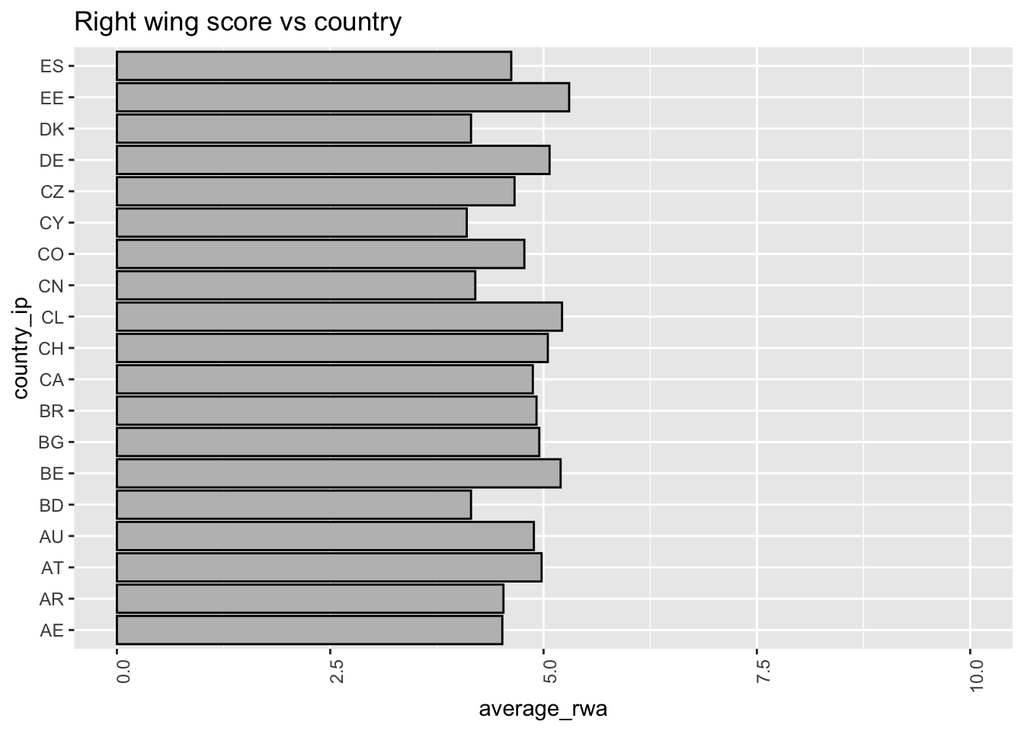

### Average RWA per urban classification

Does the urban classification have an impace on the participants RWAI? Urban classifications:

- rural,
- urban,
- suburban,

were recorded. The participants can be grouped based on their response and then the average for each classification can be calculated.

```r
rw_data %>%
  group_by(urban_classification) %>%
  summarise(mean(avg_rwa, na.rm = TRUE), .groups = "drop_last") %>%
  drop_na()
```

| urban_classification | mean(avg_rwa, na.rm = TRUE) |
| --- | --- |
| rural | 4.899926 |
| suburban | 4.909121 |
| urban | 4.845774 |